# Informe Final del Estudio sobre Adicción a las Redes Sociales

### **Pruebas de Normalidad**

Aunque `How_Many_Platforms` es discreta, se evalúa su “normalidad” para ver si puede ser aproximada por una distribución normal.

#### **a) Prueba de Shapiro-Wilk**

```
## --- Prueba de Shapiro-Wilk para How_Many_Platforms ---
```

```
##
##  Shapiro-Wilk normality test
##
## data:  platforms_count_data
## W = 0.67, p-value <2e-16
```

**Interpretación:** El p-valor es extremadamente bajo (mucho menor que $\alpha = 0.05$). Esto nos lleva a **rechazar la hipótesis nula** de normalidad. Se sugiere que la variable `How_Many_Platforms` **no sigue una distribución normal**.

### **Visualización de la Normalidad**

Las visualizaciones son cruciales para complementar las pruebas estadísticas.

#### **a) Histograma con Curva de Densidad Normal Superpuesta**

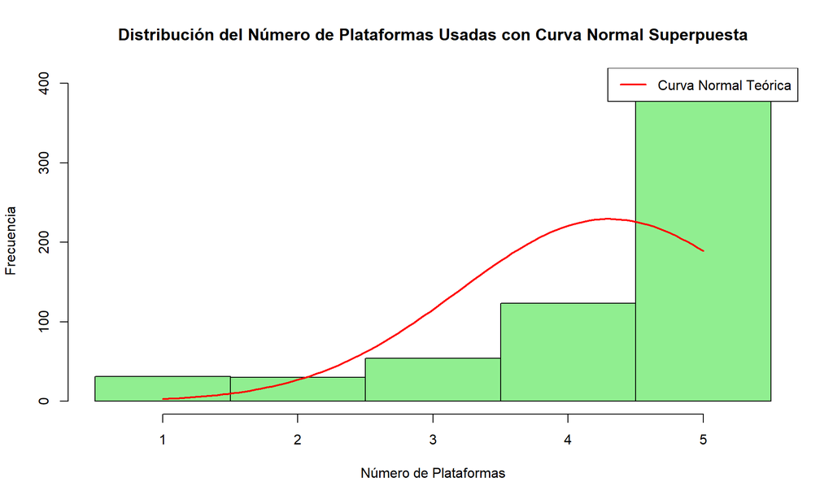

**Interpretación:**

El histograma con la curva normal superpuesta muestra que la distribución de `How_Many_Platforms` no se ajusta bien a una distribución normal.

#### **b) Gráfico Cuantil-Cuantil (Q-Q Plot)**

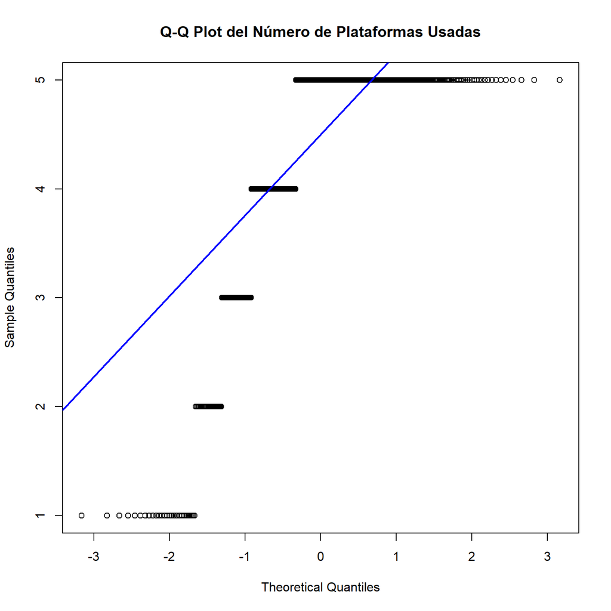

**Interpretación:**

El Q-Q plot de la variable `How_Many_Platforms` muestra una desviación clara y escalonada de la línea diagonal. Esta forma de “escalera” es característica de datos discretos que no se distribuyen normalmente. Los puntos no se alinean con la línea, lo que es una fuerte indicación de no normalidad.

### **Conclusión del Análisis Completo de ‘How_Many_Platforms’**

La variable `How_Many_Platforms` es una variable de conteo que indica el número de plataformas de redes sociales utilizadas, con una media de aproximadamente 4.3058.

- **Distribución de Poisson:** La **media (4.3058) y la varianza (1.2439) son considerablemente diferentes**, con la varianza siendo menor que la media. Esto indica **subdispersión**, por lo que la distribución de Poisson **no es un modelo adecuado** para esta variable.
- **Normalidad:** Las pruebas estadísticas (Shapiro-Wilk) y las visualizaciones (histograma y Q-Q plot) concluyen de manera consistente que **esta variable no sigue una distribución normal**. La distribución es discreta, y su forma no se asemeja a una campana.

Por lo tanto, para análisis inferenciales que involucren `How_Many_Platforms`, se debe evitar el uso de métodos que asuman una distribución normal o de Poisson estricta.

## **12. Análisis de la Variable ‘Relationship_Status’**

Finalmente, culminan los análisis con la exploración de la distribución y características de la variable `Relationship_Status` (Estado de Relación). Esta es una variable cualitativa nominal, por lo que nos centraremos en las frecuencias y proporciones de sus categorías.

### **Frecuencias y Proporciones de ‘Relationship_Status’**

```
## --- Resumen de la Variable Relationship_Status ---
```

```
##  no yes
## 355 286
```

```
## Frecuencias Absolutas:
```

```
## relationship_status_data
##  no yes
## 355 286
```

```
## Frecuencias Relativas (Proporciones):
```

```
## relationship_status_data
##     no    yes
## 0.5538 0.4462
```

```
## Número total de encuestados: 641
```

**Interpretación:**

De un total de 641 encuestados:

- 286 (44.6178%) se encuentran en una relación.
- 355 (55.3822%) están solteros.

Esto muestra una distribución con una ligera mayoría de encuestados solteros.

### **Visualización: Gráfico de Barras de ‘Relationship_Status’**

Un gráfico de barras es la visualización más adecuada para variables cualitativas, mostrando la frecuencia o proporción de cada categoría. Se ordenarán las barras por frecuencia de forma descendente para facilitar la interpretación.

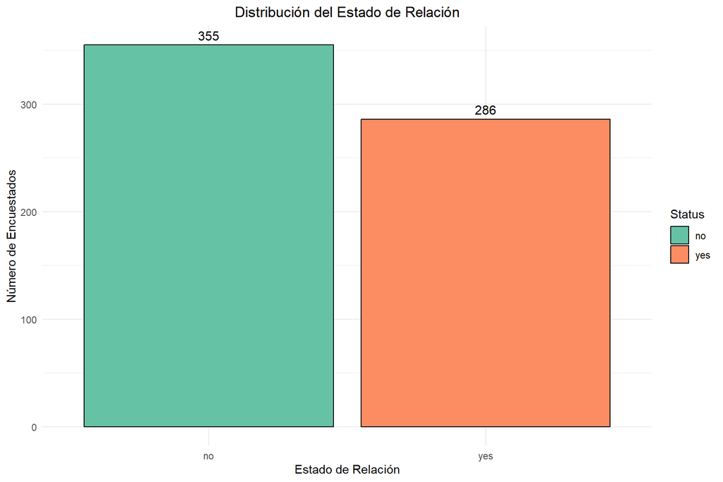

**Interpretación de la Visualización:**

El gráfico de barras confirma visualmente las proporciones calculadas, mostrando que el grupo “soltero” es el más grande, con diferencias no muy marcadas entre ellos.

### **Conclusión del Análisis de ‘Relationship_Status’**

La variable `Relationship_Status` es una variable cualitativa nominal que describe el estado de relación de los encuestados. El análisis revela que la muestra está distribuida de manera bastante uniforme entre las categorías, siendo la categoría “soltero” la más frecuente.

Dada la naturaleza cualitativa nominal de esta variable, **no se le asocia una distribución de probabilidad paramétrica** (como Binomial, Poisson, Normal o Exponencial) en el sentido de modelar conteos o mediciones continuas. El análisis descriptivo mediante tablas de frecuencia y gráficos de barras es el método más apropiado para entender su distribución y composición. Esta información es útil para caracterizar la demografía de la muestra y puede ser empleada en análisis comparativos (por ejemplo, cómo el uso de redes sociales difiere entre personas con distintos estados de relación).